# Homework - Week 08

```r
library(rethinking)
library(ggplot2)
library(dplyr)
library(tidyr)
library(purrr)
library(dagitty)
library(patchwork)
```

The data in data(Monks) are “like” and “dislike” nominations by 18 monks living in the same monastery over three time periods. Therefore the observed variables are counts from 0 to 3 of times monk A nominated monk B as liked or disliked.1 Each row in the data is a pair of monks (a dyad). The variables are: • A: Index number for first monk in dyad • B: Index number for second monk in dyad • like_AB: Number of times A nominated B as liked • like_BA: Number of times B nominated A as liked • dislike_AB: Number of times A nominated B as disliked • dislike_BA: Number of times B nominated A as disliked

## Problem 01

1. Use these data to estimate the amount of reciprocity in “like” nominations within dyads. You can ignore the “dislike” data for now. Use the social network example from the book to help, but you should modify it appropriately.

```r
data(Monks)
d <- Monks %>% rename(D = dyad_id) %>% mutate(Y=3L) %>% as_tibble()
head(d)
```

```
# A tibble: 6 × 10
      D     A     B like_AB like_BA dislike_AB dislike_BA A_name B_name      Y
  <int> <int> <int>   <int>   <int>      <int>      <int> <fct>  <fct>   <int>
1     1     1     2       0       3          0          0 ROMUL  BONAVEN     3
2     2     1     3       3       3          0          0 ROMUL  AMBROSE     3
3     3     1     4       0       0          0          0 ROMUL  BERTH       3
4     4     1     5       0       0          0          0 ROMUL  PETER       3
5     5     1     6       0       0          0          0 ROMUL  LOUIS       3
6     6     1     7       0       0          0          0 ROMUL  VICTOR      3
```

```r
N_dyads <- nrow(d)
d_list <- d %>% as.list()
d_list$N_dyads <- N_dyads

m1 <- ulam(
  alist(
    like_AB ~ binomial(Y, pAB),
    like_BA ~ binomial(Y, pBA),
    logit(pAB) <- alpha + T[D,1],
    logit(pBA) <- alpha + T[D,2],
    alpha ~ normal(0, 1),

    ## Dyad effects
    transpars> matrix[N_dyads, 2]:T <-
      compose_noncentered( rep_vector(sigma_T,2) , L_Rho_T , Z ),
    matrix[2, N_dyads]:Z ~ normal(0,1),
    cholesky_factor_corr[2]:L_Rho_T ~ lkj_corr_cholesky(2),
    sigma_T ~ exponential(1),

    ## compute correlation matrix dyad
    gq> matrix[2,2]:Rho_T <<- Chol_to_Corr(L_Rho_T)
  ),
  data = d_list, chains=4, cores=4, iter=2000
)
```

```r
precis(m1, depth=3, pars=c("alpha", "Rho_T", "sigma_T"))
```

```
                 mean        sd       5.5%      94.5%    n_eff     Rhat4
alpha      -4.1778638 0.4134443 -4.8671068 -3.5517969 3159.099 0.9996379
Rho_T[1,1]  1.0000000 0.0000000  1.0000000  1.0000000      NaN       NaN
Rho_T[1,2]  0.6334248 0.1056682  0.4534339  0.7857341 1524.536 1.0002378
Rho_T[2,1]  0.6334248 0.1056682  0.4534339  0.7857341 1524.536 1.0002378
Rho_T[2,2]  1.0000000 0.0000000  1.0000000  1.0000000      NaN       NaN
sigma_T     3.3998027 0.4260369  2.7682925  4.1322243 1802.441 0.9996219
```

The correlation is positive (0.63) and slightly high. Let’s plot the mean samples for dyads

```r
m1_post <- extract.samples(m1)

raw_likeA_effect <- apply(m1_post$T[,,1], 2, mean)
raw_likeB_effect <- apply(m1_post$T[,,2], 2, mean)

raw_scale_plot <- ggplot()+
  geom_point(
    aes(x=raw_likeA_effect, y=raw_likeB_effect), alpha=0.2) +
  geom_abline(intercept=0, slope=1, linetype=2) +
  labs(title="[Like] - Raw effect plot")
```

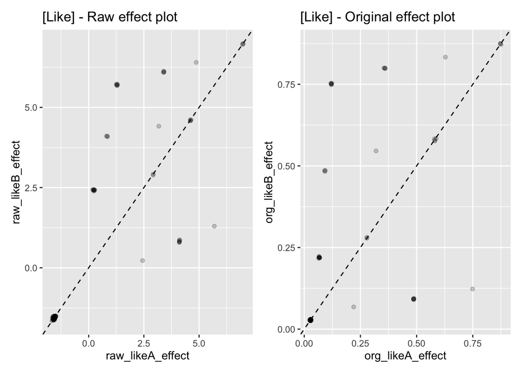

```r
m_a <- m1_post$a %>% rep(N_dyads) %>% matrix(ncol=N_dyads)
org_likeA_effect <- apply(inv_logit(m_a + m1_post$T[,,1]), 2, mean)
org_likeB_effect <- apply(inv_logit(m_a + m1_post$T[,,2]), 2, mean)

original_scale_plot <- ggplot()+
  geom_point(aes(x=org_likeA_effect, y=org_likeB_effect), alpha=0.2) +
  geom_abline(intercept=0, slope=1, linetype=2) +
  labs(title="[Like] - Original effect plot")

raw_scale_plot | original_scale_plot
```

## Problem 02

Now also analyze the “dislike” nominations. Estimate the amount of reciprocity in the “dislike” nominations and compare to the estimate from the “like” nominations. Does “like” or “dislike” have higher reciprocity? Be sure to compute the posterior contrast between the two estimates.

```r
N_dyads <- nrow(d)
d_list <- d %>% as.list()
d_list$N_dyads <- N_dyads

m2 <- ulam(
  alist(
    dislike_AB ~ binomial(Y, pAB),
    dislike_BA ~ binomial(Y, pBA),
    logit(pAB) <- alpha + T[D,1],
    logit(pBA) <- alpha + T[D,2],
    alpha ~ normal(0, 1),

    ## Dyad effects
    transpars> matrix[N_dyads, 2]:T <-
      compose_noncentered( rep_vector(sigma_T,2) , L_Rho_T , Z ),
    matrix[2, N_dyads]:Z ~ normal(0,1),
    cholesky_factor_corr[2]:L_Rho_T ~ lkj_corr_cholesky(2),
    sigma_T ~ exponential(1),

    ## compute correlation matrix dyad
    gq> matrix[2,2]:Rho_T <<- Chol_to_Corr(L_Rho_T)
  ),
  data = d_list, chains=4, cores=4, iter=2000
)
```

```r
precis(m2, depth=3, pars=c("alpha", "Rho_T", "sigma_T"))
```

```
                 mean        sd       5.5%     94.5%    n_eff    Rhat4
alpha      -4.4843990 0.4339182 -5.2042513 -3.811828 2272.045 1.001047
Rho_T[1,1]  1.0000000 0.0000000  1.0000000  1.000000      NaN      NaN
Rho_T[1,2]  0.4581712 0.1348123  0.2303006  0.655890 1040.321 1.003355
Rho_T[2,1]  0.4581712 0.1348123  0.2303006  0.655890 1040.321 1.003355
Rho_T[2,2]  1.0000000 0.0000000  1.0000000  1.000000      NaN      NaN
sigma_T     3.3359680 0.4141090  2.7084852  4.041828 1638.553 1.001407
```

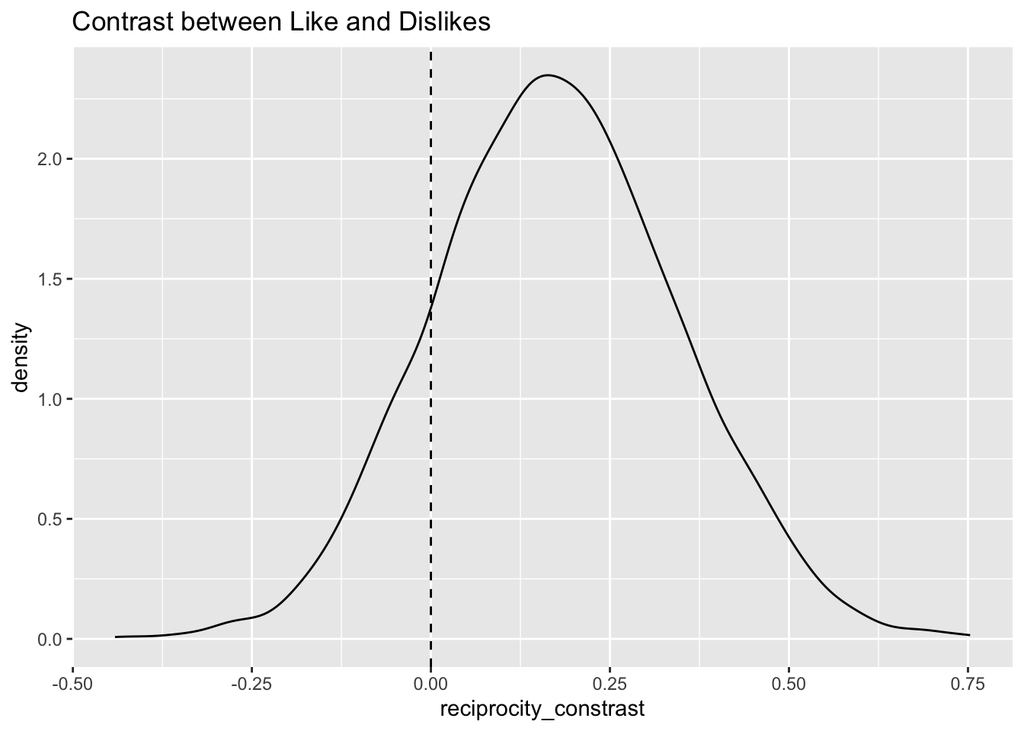

```r
m2_post <- extract.samples(m2)

reciprocity_constrast <- m1_post$Rho_T[,1,2] - m2_post$Rho_T[,1,2]

ggplot() +
  geom_density(aes(x=reciprocity_constrast)) +
  geom_vline(xintercept = 0, linetype = 2) +
  labs(title = "Contrast between Like and Dislikes")
```

Let’s plot the mean samples for dyads.

```r
raw_dislikeA_effect <- apply(m2_post$T[,,1], 2, mean)
raw_dislikeB_effect <- apply(m2_post$T[,,2], 2, mean)

raw_dislike_scale_plot <- ggplot()+
  geom_point(
    aes(x=raw_dislikeA_effect, y=raw_dislikeB_effect), alpha=0.2) +
  geom_abline(intercept=0, slope=1, linetype=2) +
  labs(title="[Dislike] - Raw effect plot")
```

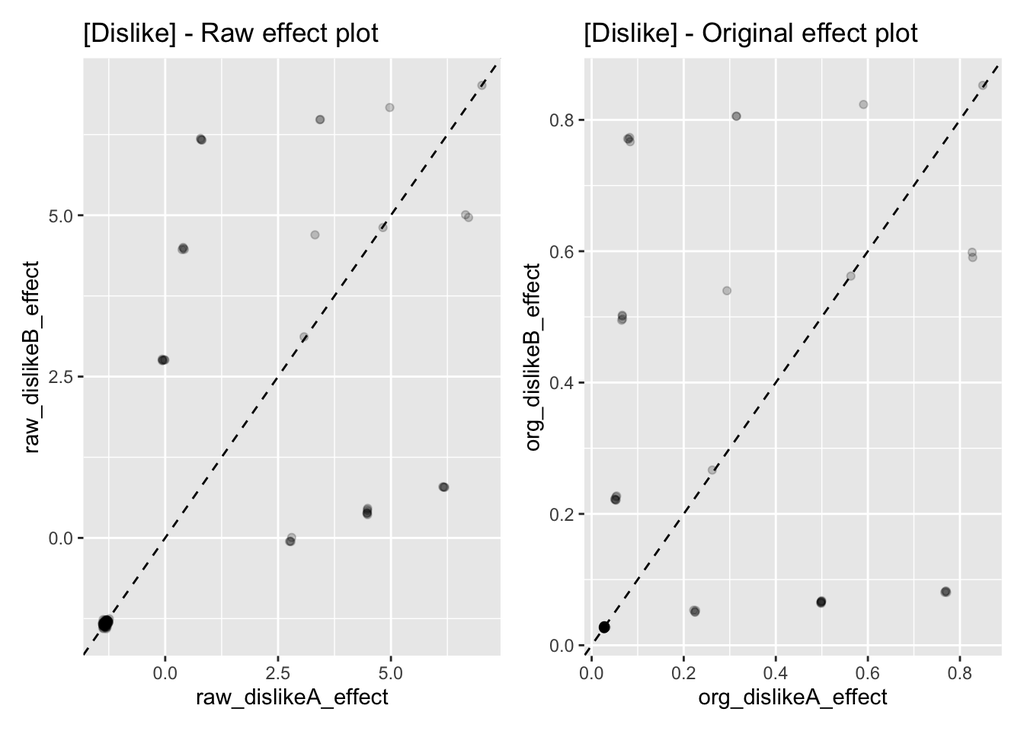

```r
m_a <- m2_post$a %>% rep(N_dyads) %>% matrix(ncol=N_dyads)
org_dislikeA_effect <- apply(inv_logit(m_a + m2_post$T[,,1]), 2, mean)
org_dislikeB_effect <- apply(inv_logit(m_a + m2_post$T[,,2]), 2, mean)

original_dislike_scale_plot <- ggplot()+
  geom_point(aes(x=org_dislikeA_effect, y=org_dislikeB_effect), alpha=0.2) +
  geom_abline(intercept=0, slope=1, linetype=2) +
  labs(title="[Dislike] - Original effect plot")

raw_dislike_scale_plot | original_dislike_scale_plot
```

## Problem 03

Now consider generalized liking and disliking. Add generalized “receiving” parameters to the model, analogous to receiving varying effects from the sharing example in the book/lecture. (Each monk only named 3 likes and 3 dislikes each time, so the amount of “giving” is fixed by design in these data.) Can you identify any individuals who are particularly liked/disliked, independent of the dyadic relations?

```r
N_dyads <- nrow(d)
d_list <- d %>% as.list()
d_list$N_dyads <- N_dyads
d_list$M <- c(d_list$A, d_list$B) %>% unique() # Monk

m3 <- ulam(
  alist(
    like_AB ~ binomial(Y, pAB),
    like_BA ~ binomial(Y, pBA),
    logit(pAB) <- alpha + T[D,1] + R[B],
    logit(pBA) <- alpha + T[D,2] + R[A],
    alpha ~ normal(0, 1),

    ## Monks effect
    R[M] ~ normal(alpha_M, sigma_M),
    alpha_M ~ normal(0,1),
    sigma_M~ exponential(1),

    ## Dyad effects
    transpars> matrix[N_dyads, 2]:T <-
      compose_noncentered( rep_vector(sigma_T,2) , L_Rho_T , Z ),
    matrix[2, N_dyads]:Z ~ normal(0,1),
    cholesky_factor_corr[2]:L_Rho_T ~ lkj_corr_cholesky(2),
    sigma_T ~ exponential(1),

    ## compute correlation matrix dyad
    gq> matrix[2,2]:Rho_T <<- Chol_to_Corr(L_Rho_T)
  ),
  data = d_list, chains=4, cores=4, iter=2000
)
```

```r
m3_post <- extract.samples(m3)
str(m3_post)
```

```
List of 9
 $ alpha  : num [1:4000(1d)] -3.15 -2.21 -3.63 -1.31 -2.54 ...
 $ R      : num [1:4000, 1:18] 0.0745 -3.1061 -2.214 -3.7038 -1.1469 ...
 $ alpha_M: num [1:4000(1d)] -1.55 -2.89 -1.8 -3.48 -1.74 ...
 $ sigma_M: num [1:4000(1d)] 0.946 1.253 1.471 0.967 0.489 ...
 $ Z      : num [1:4000, 1:2, 1:153] 0.269 1.155 1.295 0.404 0.762 ...
 $ L_Rho_T: num [1:4000, 1:2, 1:2] 1 1 1 1 1 1 1 1 1 1 ...
 $ sigma_T: num [1:4000(1d)] 3.49 3.74 4.63 3.95 3.35 ...
 $ Rho_T  : num [1:4000, 1:2, 1:2] 1 1 1 1 1 1 1 1 1 1 ...
 $ T      : num [1:4000, 1:153, 1:2] 0.938 4.325 5.994 1.6 2.55 ...
 - attr(*, "source")= chr "ulam posterior: 4000 samples from object"
```

### Liked monks

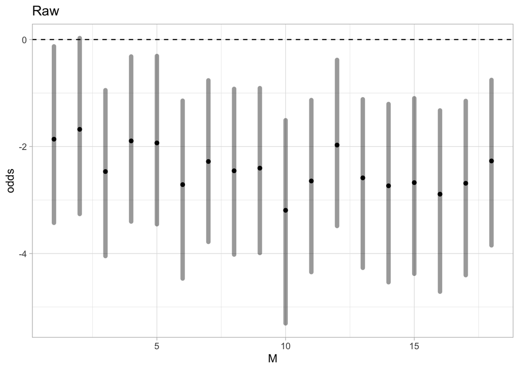

```r
raw_like_monk_effect <- with(m3_post, R)

mean_p <- raw_like_monk_effect %>% apply(MARGIN=2, FUN=mean)
p89interval <- raw_like_monk_effect %>%
  apply(MARGIN=2, FUN=PI) %>%
  t
raw_like_to_plot <- tibble(
  p = mean_p,
  p5 = p89interval[,1],
  p94 = p89interval[,2]
) %>%
  mutate(M = row_number())

raw_like_monk_plot <- ggplot(raw_like_to_plot) +
  geom_point(aes(x = M, y = p)) +
  geom_segment(
    aes(x=M, xend=M, y=p5, yend=p94),
    alpha = 0.4, linewidth=2, lineend = "round"
  ) +
  geom_hline(aes(yintercept=0), linetype=2) +
  labs(title="Raw", y="odds") +
  theme_light()

raw_like_monk_plot
```

```r
N_dyads <- nrow(d)
d_list <- d %>% as.list()
d_list$N_dyads <- N_dyads
d_list$M <- c(d_list$A, d_list$B) %>% unique() # Monk
N_monks <- d_list$M %>% length()
d_list$N_monks <- N_monks

m4 <- ulam(
  alist(
    # Like
    like_AB ~ binomial(Y, pAB),
    like_BA ~ binomial(Y, pBA),
    logit(pAB) <- alpha + T[D,1] + R[B,1],
    logit(pBA) <- alpha + T[D,2] + R[A,1],
    alpha ~ normal(0, 1),

    #Dislike
    dislike_AB ~ binomial(Y, pABd),
    dislike_BA ~ binomial(Y, pBAd),
    logit(pABd) <- alpha_d + Td[D,1]+ R[B,2],
    logit(pBAd) <- alpha_d + Td[D,2]+ R[A,2],
    alpha_d ~ normal(0, 1),

    ## Monks effect
    vector[2]:R[N_monks] ~ multi_normal(0, Rho_M, sigma_M),
    Rho_M ~ lkj_corr(4),
    sigma_M~ exponential(1),

    ## Dyad effects - Like
    transpars> matrix[N_dyads, 2]:T <-
      compose_noncentered( rep_vector(sigma_T,2) , L_Rho_T , Z ),
    matrix[2, N_dyads]:Z ~ normal(0,1),
    cholesky_factor_corr[2]:L_Rho_T ~ lkj_corr_cholesky(2),
    sigma_T ~ exponential(1),

    ## Dyad effects - Dislike
    transpars> matrix[N_dyads, 2]:Td <-
      compose_noncentered( rep_vector(sigma_Td,2) , L_Rho_Td , Zd ),
    matrix[2, N_dyads]:Zd ~ normal(0,1),
    cholesky_factor_corr[2]:L_Rho_Td ~ lkj_corr_cholesky(2),
    sigma_Td ~ exponential(1),

    ## compute correlation matrix dyad
    gq> matrix[2,2]:Rho_T <<- Chol_to_Corr(L_Rho_T),
    gq> matrix[2,2]:Rho_Td <<- Chol_to_Corr(L_Rho_T)
  ),
  data = d_list, chains=4, cores=4, iter=2000
)
```

```r
precis(m3, depth=3, pars=c("sigma_T","R"))
```

```
             mean        sd      5.5%       94.5%     n_eff    Rhat4
sigma_T  3.709221 0.4966058  2.973072  4.54059845 1305.4858 1.006306
R[1]    -1.862255 1.0255308 -3.425837 -0.12772210  680.9411 1.005243
R[2]    -1.678282 1.0410915 -3.260716  0.02730568  645.9539 1.008976
R[3]    -2.467654 0.9675620 -4.047019 -0.94651417  702.2713 1.003392
R[4]    -1.894749 0.9871675 -3.401883 -0.31669549  676.5383 1.006424
R[5]    -1.932908 0.9816852 -3.452639 -0.30745944  698.7985 1.005540
R[6]    -2.711762 1.0367112 -4.467295 -1.14314895  737.7234 1.004968
R[7]    -2.279356 0.9626952 -3.782365 -0.76282483  750.0638 1.002531
R[8]    -2.453228 0.9749365 -4.019300 -0.92202932  793.0789 1.001729
R[9]    -2.403627 0.9730843 -3.990116 -0.90829478  802.6998 1.000617
R[10]   -3.191734 1.1977887 -5.305584 -1.50840625  620.9842 1.006647
R[11]   -2.643788 1.0264914 -4.347358 -1.13133680  831.5117 1.001805
R[12]   -1.972035 0.9743482 -3.485005 -0.38036549  670.2528 1.005718
R[13]   -2.585414 0.9879372 -4.267440 -1.11675390  725.9376 1.002508
R[14]   -2.734031 1.0428553 -4.536745 -1.20496540  708.0379 1.003568
R[15]   -2.674254 1.0334193 -4.378524 -1.09764320  752.9652 1.003093
R[16]   -2.890172 1.0747619 -4.713203 -1.32508790  642.1075 1.002774
R[17]   -2.686867 1.0137087 -4.404285 -1.14707745  775.8257 1.002039
R[18]   -2.269416 0.9652811 -3.847186 -0.75496565  823.9205 1.000658
```

```r
precis(m4, depth=3, pars=c("sigma_T","sigma_M", "R", "Rho_M", "Rho_T", "Rho_Td"))
```

```
                   mean        sd       5.5%      94.5%     n_eff     Rhat4
sigma_T      3.41070124 0.4412805  2.7530302  4.1677975 1599.5125 1.0029630
sigma_M[1]   0.65547031 0.4827863  0.0693932  1.4773463  157.1613 1.0490469
sigma_M[2]   2.43794817 0.8689875  1.3686083  4.0399133  840.6556 1.0013442
R[1,1]       0.29779779 0.6195412 -0.4776130  1.4518460 1051.1451 1.0080890
R[1,2]      -1.04669713 1.2804399 -3.2641034  0.8279544 1729.9815 1.0005023
R[2,1]       0.44510879 0.6698810 -0.3406886  1.6973822  554.5644 1.0088865
R[2,2]      -3.14632277 2.0238815 -6.7101717 -0.5057160 1509.8150 0.9997561
R[3,1]      -0.19379041 0.6491085 -1.4028151  0.6952363 1199.2123 1.0069248
R[3,2]      -3.54793277 2.1038225 -7.2907817 -0.7897743 1183.0957 1.0006753
R[4,1]       0.28035267 0.6034027 -0.4939648  1.4163650 1151.8385 1.0051085
R[4,2]      -0.08604414 1.1228615 -1.9305662  1.5987851 1737.7686 1.0023164
R[5,1]       0.23838576 0.5851525 -0.5585119  1.2952129 1350.2001 1.0052746
R[5,2]       1.95708313 0.9742937  0.3786731  3.4882351 2053.9172 1.0004515
R[6,1]      -0.42002911 0.7429183 -1.8153125  0.4096822  621.5402 1.0140540
R[6,2]      -3.52455216 2.1098531 -7.2465843 -0.7737313 1332.6261 1.0005934
R[7,1]      -0.05737925 0.5552775 -0.9965737  0.7910011 3526.9325 1.0026171
R[7,2]       0.40879601 1.0963869 -1.4587636  2.0475255 1668.5173 1.0001986
R[8,1]      -0.18775256 0.6387598 -1.3565501  0.6755645 1604.0107 1.0024583
R[8,2]      -2.01626058 1.6027679 -4.8774057  0.1890713 1232.7989 1.0009221
R[9,1]      -0.16217025 0.5969203 -1.2214240  0.6805595 1900.2256 1.0024256
R[9,2]      -1.36598234 1.3042760 -3.5937274  0.4540067 1450.3474 1.0002557
R[10,1]     -0.77426892 1.0008011 -2.7205635  0.2050342  331.4219 1.0208448
R[10,2]      1.78602319 1.0248375  0.1217687  3.3766534 1756.7336 0.9997969
R[11,1]     -0.31969960 0.6819090 -1.5504322  0.5089740  835.6082 1.0088104
R[11,2]     -1.85743772 1.4461272 -4.3701993  0.1690614 1453.8329 0.9999950
R[12,1]      0.16967064 0.6018259 -0.7117486  1.2310769 2148.1479 1.0000172
R[12,2]     -3.53395851 2.1054797 -7.3545500 -0.7621565 1245.7437 1.0023260
R[13,1]     -0.29146654 0.6528425 -1.5381092  0.5085751  783.6982 1.0069475
R[13,2]     -1.00934018 1.2665696 -3.1814488  0.8114043 1674.6237 1.0012016
R[14,1]     -0.41846069 0.7337334 -1.8139414  0.4313711  561.6530 1.0160442
R[14,2]     -2.37428092 1.5779311 -5.0905236 -0.1778192 1456.9663 0.9991712
R[15,1]     -0.34912032 0.6776075 -1.6335866  0.4436191  654.2410 1.0125510
R[15,2]     -1.38592908 1.3629045 -3.8098303  0.5507373 1102.1986 1.0018495
R[16,1]     -0.54264576 0.8212503 -2.1161692  0.3132949  344.9224 1.0212264
R[16,2]      0.85913752 1.0499711 -0.8957404  2.4542698 1556.4959 1.0000784
R[17,1]     -0.36419067 0.6955660 -1.6675905  0.4297472  613.5272 1.0154256
R[17,2]     -0.29983449 1.1707601 -2.3290950  1.4034663 1405.1892 1.0005579
R[18,1]     -0.04129973 0.6052715 -1.0456017  0.8977681 3543.4882 0.9998876
R[18,2]     -2.41829552 1.5981740 -5.2471756 -0.1932423 1262.7043 1.0009389
Rho_M[1,1]   1.00000000 0.0000000  1.0000000  1.0000000       NaN       NaN
Rho_M[1,2]   0.01089830 0.3121014 -0.4922034  0.5102482 2220.3352 1.0003222
Rho_M[2,1]   0.01089830 0.3121014 -0.4922034  0.5102482 2220.3352 1.0003222
Rho_M[2,2]   1.00000000 0.0000000  1.0000000  1.0000000       NaN       NaN
Rho_T[1,1]   1.00000000 0.0000000  1.0000000  1.0000000       NaN       NaN
Rho_T[1,2]   0.64929112 0.1105471  0.4626183  0.8151004 1175.7646 1.0046407
Rho_T[2,1]   0.64929112 0.1105471  0.4626183  0.8151004 1175.7646 1.0046407
Rho_T[2,2]   1.00000000 0.0000000  1.0000000  1.0000000       NaN       NaN
Rho_Td[1,1]  1.00000000 0.0000000  1.0000000  1.0000000       NaN       NaN
Rho_Td[1,2]  0.64929112 0.1105471  0.4626183  0.8151004 1175.7646 1.0046407
Rho_Td[2,1]  0.64929112 0.1105471  0.4626183  0.8151004 1175.7646 1.0046407
Rho_Td[2,2]  1.00000000 0.0000000  1.0000000  1.0000000       NaN       NaN
```

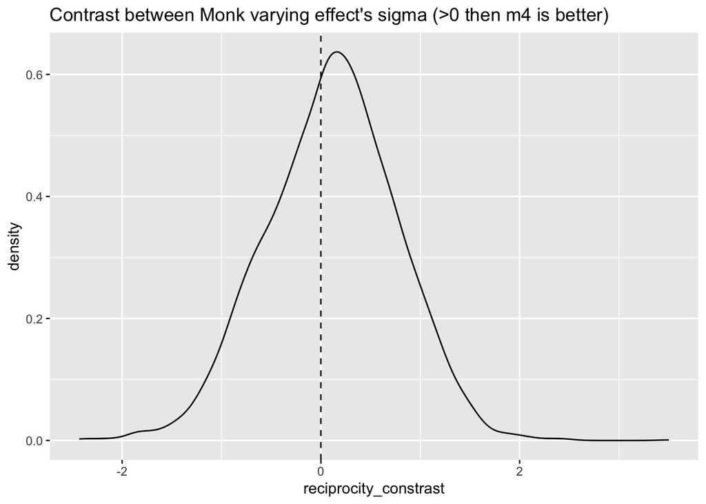

```r
m3_post <- extract.samples(m3)
m4_post <- extract.samples(m4)

reciprocity_constrast <- m3_post$sigma_M - m4_post$sigma_M[,1]

ggplot() +
  geom_density(aes(x=reciprocity_constrast)) +
  geom_vline(xintercept = 0, linetype = 2) +
  labs(title = "Contrast between Monk varying effect's sigma (>0 then m4 is better)")
```

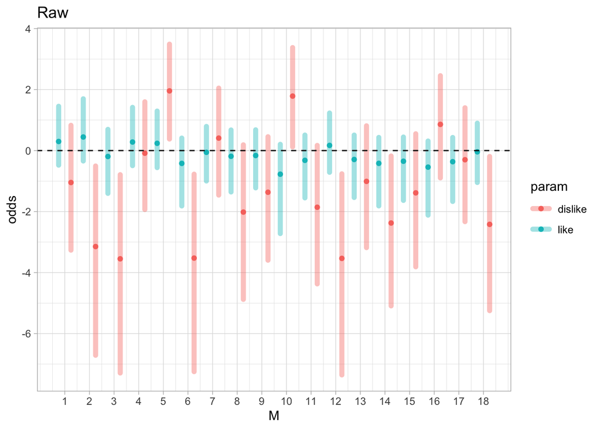

```r
raw_like_monk_effect <- with(m4_post, R[,,1])

mean_p <- raw_like_monk_effect %>% apply(MARGIN=2, FUN=mean)
p89interval <- raw_like_monk_effect %>%
  apply(MARGIN=2, FUN=PI) %>%
  t
raw_like_to_plot <- tibble(
  p = mean_p,
  p5 = p89interval[,1],
  p94 = p89interval[,2]
) %>%
  mutate(M = row_number() - 0.25,
         param="like")

raw_dislike_monk_effect <- with(m4_post, R[,,2])

mean_p <- raw_dislike_monk_effect %>% apply(MARGIN=2, FUN=mean)
p89interval <- raw_dislike_monk_effect %>%
  apply(MARGIN=2, FUN=PI) %>%
  t
raw_dislike_to_plot <- tibble(
  p = mean_p,
  p5 = p89interval[,1],
  p94 = p89interval[,2]
) %>%
  mutate(M = row_number() + 0.25,
         param="dislike")

raw_m4_like_monk_plot <- bind_rows(raw_like_to_plot, raw_dislike_to_plot) %>%
  ggplot() +
  geom_point(aes(x = M, y = p, color=param)) +
  geom_segment(
    aes(x=M, xend=M, y=p5, yend=p94, color=param, group=param),
    alpha = 0.4, linewidth=2, lineend = "round"
  ) +
  scale_x_continuous(breaks = 1:N_monks) +
  geom_hline(aes(yintercept=0), linetype=2) +
  labs(title="Raw", y="odds") +
  theme_light()

raw_m4_like_monk_plot
```

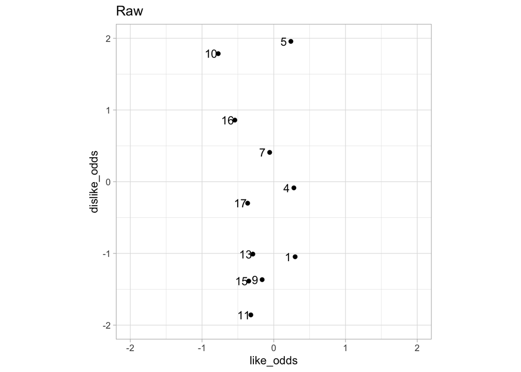

```r
to_plot <- inner_join(
  raw_like_to_plot %>% transmute(M = M + 0.25, like_odds=p),
  raw_dislike_to_plot %>% transmute(M = M - 0.25, dislike_odds=p),
  by = "M"
)
raw_m4_like_monk_plot <- ggplot(to_plot) +
  geom_point(aes(x = like_odds, y = dislike_odds)) +
  geom_text(aes(x = like_odds, y = dislike_odds,label=M), nudge_x = -0.1) +
  scale_x_continuous(limits = c(-2,2)) +
  scale_y_continuous(limits = c(-2,2)) +
  coord_fixed() +
  labs(title="Raw") +
  theme_light()

raw_m4_like_monk_plot
```